# SI140A Final Project - Phase Transition

Team members:

- Hengyu Ai (aihy2023\<at>shanghaitech.edu.cn)
- Zebang He (hezb2023\<at>shanghaitech.edu.cn)
- Sizhe Zhao (zhaoszh2023\<at>shanghaitech.edu.cn)

Contributions:

- Hengyu Ai: Implement the percolation model
- Zebang He: Implement the acceleration of the Ising model
- Sizhe Zhao: Give out proof in Part II Task A & implement the simulation of the Ising model

## Part I: Percolation

### Problem Description

Using an $n \times n$ grid as a percolation model, we want to find the percolation threshold $p^*$, which is the probability that a site is open, such that the system percolates. A system percolates if there is a path of open sites from the top to the bottom of the grid.

### Solution

`numpy.random.choice` is used to generate random numbers. We first generate a random grid with a given probability $p$.

Then we use breadth-first search to find the connected components of the grid. If there is a connected component that connects the top and bottom of the grid (a full open site), we say the system percolates.

We pick $p$ from $0$ to $1$ and calculate the percolation probability by 5000 randomlly generated $n \times n$ grids. The percolation threshold is the smallest $p$ such that the percolation probability is larger than 0.5.

```
Threshold for n = 20: 0.5902776718139648
```

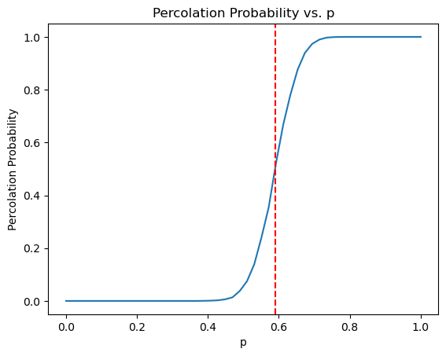

```
Threshold for n = 50: 0.5921916961669922
```

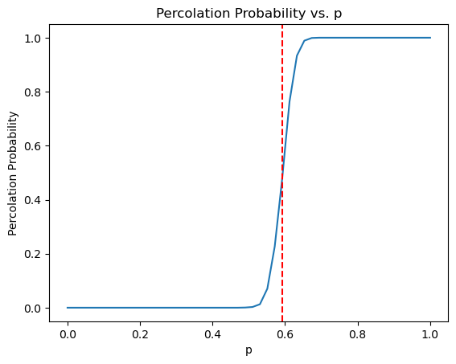

```
Threshold for n = 100: 0.5922842025756836
```

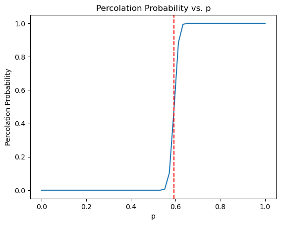

```python
import numpy as np

"""
Generate a grid of size 'n' x 'n' with each cell having a probability 'p' of being open.
"""


def generate_grid(n: int, p: float) -> np.ndarray:
    return np.random.choice([0, 1], (n, n), p=[p, 1 - p])


"""
Use Breadth First Search to check if the grid percolates from the top to the bottom.
"""


def check_percolation(grid: np.ndarray) -> bool:
    q = []
    n = grid.shape[0]
    visited = np.zeros((n, n), dtype=bool)
    for i in range(n):
        if grid[i, 0] == 0:
            q.append((i, 0))
            visited[i, 0] = True
    while q:
        x, y = q.pop(0)
        if y == n - 1:
            return True
        for dx, dy in [(0, 1), (1, 0), (0, -1), (-1, 0)]:
            nx, ny = x + dx, y + dy
            if 0 <= nx < n and 0 <= ny < n and grid[nx, ny] == 0 and not visited[nx, ny]:
                q.append((nx, ny))
                visited[nx, ny] = True
    return False


"""
Calculate the probability of percolation using Monte Carlo Simulation.
"""


def calc_percolation_probability(n: int, p: float, num_trials: int) -> float:
    count = 0
    for _ in range(num_trials):
        grid = generate_grid(n, p)
        if check_percolation(grid):
            count += 1
    return count / num_trials


def calc_threshold(n: int, num_trials: int) -> float:
    lo, hi = 0.0, 1.0
    while hi - lo > 1e-6:
        mid = (lo + hi) / 2
        if calc_percolation_probability(n, mid, num_trials) < 0.5:
            lo = mid
        else:
            hi = mid
    return lo


def plot_probability(n: int, num_trials: int, threshold: float) -> None:
    import matplotlib.pyplot as plt
    x = np.linspace(0, 1, 50)
    y = [calc_percolation_probability(n, p, num_trials) for p in x]
    plt.plot(x, y)
    plt.axvline(x=threshold, color='r', linestyle='--')
    plt.xlabel('p')
    plt.ylabel('Percolation Probability')
    plt.title('Percolation Probability vs. p')
    plt.show()


def main():
    num_trials = 5000
    for n in [20, 50, 100]:
        threshold = calc_threshold(n, num_trials)
        print(f"Threshold for n = {n}: {threshold}")
        plot_probability(n, num_trials, threshold)



main()
```

## Part II: Ising Model

## Solution

### Task A

$ \begin{aligned} P(\sigma_k=+1|\boldsymbol{\sigma}_{-k}) &= \frac{P(\boldsymbol{\sigma}_{-k} \cup \{\sigma_k=+1\})}{P(\boldsymbol{\sigma}_{-k})} \\ &= \frac{P(\boldsymbol{\sigma}_{-k} \cup \{\sigma_k=+1\})}{P(\boldsymbol{\sigma}_{-k} \cup \{\sigma_k=+1\} \cup \boldsymbol{\sigma}_{-k} \cup \{\sigma_k=-1\})} \\ &= \frac{P(\boldsymbol{\sigma}_{-k} \cup \{\sigma_k=+1\})}{P(\boldsymbol{\sigma}_{-k} \cup \{\sigma_k=+1\}) + P(\boldsymbol{\sigma}_{-k} \cup \{\sigma_k=-1\})} \\ &= \frac{\pi_{\boldsymbol{\sigma}_{-k} \cup \{\sigma_k=+1\}}}{\pi_{\boldsymbol{\sigma}_{-k} \cup \{\sigma_k=+1\}} + \pi_{\boldsymbol{\sigma}_{-k} \cup \{\sigma_k=-1\}}} \\ &= \frac{e^{-\beta H(\boldsymbol{\sigma}_{-k} \cup \{\sigma_k=+1\})}}{e^{-\beta H(\boldsymbol{\sigma}_{-k} \cup \{\sigma_k=+1\})} + e^{-\beta H(\boldsymbol{\sigma}_{-k} \cup \{\sigma_k=-1\})}} \\ &= \frac{e^{-\beta (- \sum_{v,w \not\sim k} \sigma_v \sigma_w - \sum_{v \sim k} \sigma_v)}}{e^{-\beta (- \sum_{v,w \not\sim k} \sigma_v \sigma_w - \sum_{v \sim k} \sigma_v)} + e^{-\beta (- \sum_{v,w \not\sim k} \sigma_v \sigma_w + \sum_{v \sim k} \sigma_v)}} \\ &= \frac{e^{\beta (\sum_{v,w \not\sim k} \sigma_v \sigma_w + \sum_{v \sim k} \sigma_v)}}{e^{\beta (\sum_{v,w \not\sim k} \sigma_v \sigma_w + \sum_{v \sim k} \sigma_v)} + e^{\beta (\sum_{v,w \not\sim k} \sigma_v \sigma_w - \sum_{v \sim k} \sigma_v)}} \\ &= \frac{1}{1 + \frac{e^{\beta (\sum_{v,w \not\sim k} \sigma_v \sigma_w - \sum_{v \sim k} \sigma_v)}}{e^{\beta (\sum_{v,w \not\sim k} \sigma_v \sigma_w + \sum_{v \sim k} \sigma_v)}}} \\ &= \frac{1}{1 + e^{\beta (\sum_{v,w \not\sim k} \sigma_v \sigma_w - \sum_{v \sim k} \sigma_v - \sum_{v,w \not\sim k} \sigma_v \sigma_w - \sum_{v \sim k} \sigma_v)}} \\ &= \frac{1}{1 + e^{-2\beta \sum_{v \sim k} \sigma_v}} \end{aligned} $

$ \begin{aligned} P(\sigma_k=-1|\boldsymbol{\sigma}_{-k}) &= \frac{P(\boldsymbol{\sigma}_{-k} \cup \{\sigma_k=+1\})}{P(\boldsymbol{\sigma}_{-k})} \\ &= \frac{P(\boldsymbol{\sigma}_{-k} \cup \{\sigma_k=-1\})}{P(\boldsymbol{\sigma}_{-k} \cup \{\sigma_k=+1\} \cup \boldsymbol{\sigma}_{-k} \cup \{\sigma_k=-1\})} \\ &= \frac{P(\boldsymbol{\sigma}_{-k} \cup \{\sigma_k=-1\})}{P(\boldsymbol{\sigma}_{-k} \cup \{\sigma_k=+1\}) + P(\boldsymbol{\sigma}_{-k} \cup \{\sigma_k=-1\})} \\ &= \frac{\pi_{\boldsymbol{\sigma}_{-k} \cup \{\sigma_k=-1\}}}{\pi_{\boldsymbol{\sigma}_{-k} \cup \{\sigma_k=+1\}} + \pi_{\boldsymbol{\sigma}_{-k} \cup \{\sigma_k=-1\}}} \\ &= \frac{e^{-\beta H(\boldsymbol{\sigma}_{-k} \cup \{\sigma_k=-1\})}}{e^{-\beta H(\boldsymbol{\sigma}_{-k} \cup \{\sigma_k=+1\})} + e^{-\beta H(\boldsymbol{\sigma}_{-k} \cup \{\sigma_k=-1\})}} \\ &= \frac{e^{-\beta (- \sum_{v,w \not\sim k} \sigma_v \sigma_w + \sum_{v \sim k} \sigma_v)}}{e^{-\beta (- \sum_{v,w \not\sim k} \sigma_v \sigma_w - \sum_{v \sim k} \sigma_v)} + e^{-\beta (- \sum_{v,w \not\sim k} \sigma_v \sigma_w + \sum_{v \sim k} \sigma_v)}} \\ &= \frac{e^{\beta (\sum_{v,w \not\sim k} \sigma_v \sigma_w - \sum_{v \sim k} \sigma_v)}}{e^{\beta (\sum_{v,w \not\sim k} \sigma_v \sigma_w + \sum_{v \sim k} \sigma_v)} + e^{\beta (\sum_{v,w \not\sim k} \sigma_v \sigma_w - \sum_{v \sim k} \sigma_v)}} \\ &= \frac{1}{1 + \frac{e^{\beta (\sum_{v,w \not\sim k} \sigma_v \sigma_w + \sum_{v \sim k} \sigma_v)}}{e^{\beta (\sum_{v,w \not\sim k} \sigma_v \sigma_w - \sum_{v \sim k} \sigma_v)}}} \\ &= \frac{1}{1 + e^{\beta (\sum_{v,w \not\sim k} \sigma_v \sigma_w + \sum_{v \sim k} \sigma_v - \sum_{v,w \not\sim k} \sigma_v \sigma_w + \sum_{v \sim k} \sigma_v)}} \\ &= \frac{1}{1 + e^{2\beta \sum_{v \sim k} \sigma_v}} \end{aligned} $

### Task B & C

Then we find the simulation is a CPU-bound task, the nested loop in the simulation is the most time-consuming part. And because of the GIL in Python, we cannot use multi-threading to speed up the simulation.

So we introduced taichi to accelerate the simulation. We use the `ti.field` to represent the spins and the `ti.kernel` to update the spins.

Therefore we highly recommend you to run CUDA version if your computer supports CUDA acceleration.

#### Original

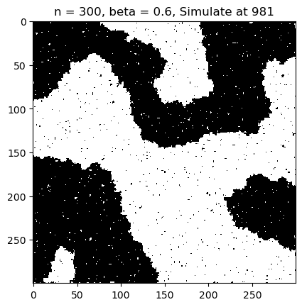

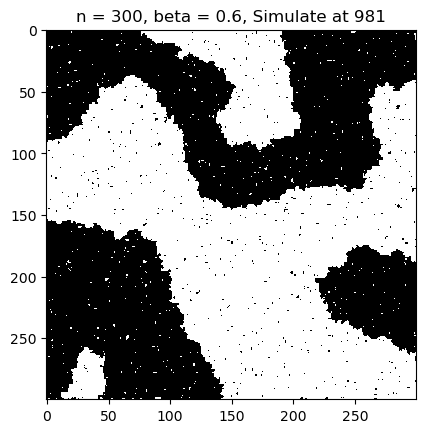

```python
import numpy as np
import matplotlib.pyplot as plt
from matplotlib.colors import ListedColormap
from IPython.display import clear_output
from time import sleep


class IsingModel:
    def __init__(self, n, beta):
        self.n = n
        self.beta = beta
        self.lattice = np.random.choice([-1, 1], size=(n, n))

    def simulate(self):
        old_lattice = self.lattice

        for i in range(self.n):
            for j in range(self.n):
                x = 0
                if i - 1 >= 0:
                    x += old_lattice[i - 1, j]
                if i + 1 < self.n:
                    x += old_lattice[i + 1, j]
                if j - 1 >= 0:
                    x += old_lattice[i, j - 1]
                if j + 1 < self.n:
                    x += old_lattice[i, j + 1]

                if np.random.random() <= 1 / (1 + np.exp(-2 * self.beta * x)):
                    self.lattice[i, j] = 1
                else:
                    self.lattice[i, j] = -1

    def show(self, n):
        clear_output(wait=True)
        cmap = ListedColormap(["0", "1"])
        plt.imshow(model.lattice, cmap=cmap)
        plt.title(f"n = {self.n}, beta = {self.beta}, Simulate at {n}")
        # plt.show()
        display(plt.gcf())


for n, betas in [(100, [-1, 0, 0.441, 0.8]), (300, [-5, 0.2, 0.441, 0.6])]:
    for beta in betas:
        model = IsingModel(n, beta)
        model.show(0)
        for i in range(1000):
            model.simulate()
            if i % 20 == 0:
                model.show(i+1)
```

### Task B & C Result

1. **Parameter $\beta$**:
   - $\beta$ represents the inverse of the temperature
   - At high temperatures (low $\beta$), thermal fluctuations dominate, and the spins in the lattice are randomly oriented, resulting in a disordered phase with no net magnetization.
   - At low temperatures (high $\beta$), the interaction between neighboring spins becomes significant, leading to an ordered phase where spins align either up or down, resulting in a non-zero net magnetization.
2. **Lattice Size $n$**:
   - The size of the lattice ($n \times n$) affects the critical temperature at which the phase transition occurs.
   - In smaller lattices, finite-size effects can smooth out the phase transition, making it less sharp compared to larger lattices.
   - As the lattice size increases, the phase transition becomes more pronounced, and the critical temperature approaches the theoretical value for an infinite lattice.

### Observations from Simulations

#### Taichi + CUDA + Branch Reduce

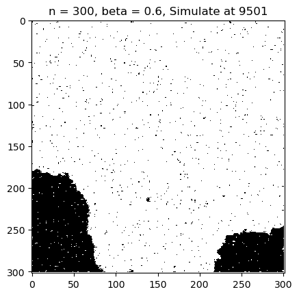

```
Simluation time elapsed:  0.05391645431518555
```

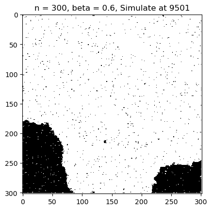

```python
import numpy as np
import matplotlib.pyplot as plt
from matplotlib.colors import ListedColormap
from IPython.display import clear_output
from time import sleep, time
import taichi as ti

ti.init(arch=ti.cuda)

@ti.data_oriented
class IsingModel:
    def __init__(self, n, beta):
        self.n = n
        self.beta = beta
        self.lattice = ti.field(dtype=ti.i32, shape=(n+2, n+2))
        self.initialize_lattice()

    @ti.kernel
    def initialize_lattice(self):
        self.lattice.fill(0)
        for i in range(1, self.n+1):
            for j in range(1, self.n+1):
                self.lattice[i, j] = ti.random(ti.i32) * 2 - 1

    @ti.kernel
    def simulate(self):
        ti.loop_config(parallelize=8, block_dim=16)
        for i in range(1, self.n+1):
            # ti.loop_config(parallelize=8, block_dim=16)
            for j in range(1, self.n+1):
                x = self.lattice[i - 1, j]
                x += self.lattice[i + 1, j]
                x += self.lattice[i, j - 1]
                x += self.lattice[i, j + 1]

                if ti.random() <= 1 / (1 + ti.exp(-2 * self.beta * x)):
                    self.lattice[i, j] = 1
                else:
                    self.lattice[i, j] = -1

    def show(self, n):
        clear_output(wait=True)
        cmap = ListedColormap(["0", "1"])
        plt.imshow(self.lattice.to_numpy(), cmap=cmap)
        plt.title(f"n = {self.n}, beta = {self.beta}, Simulate at {n}")
        display(plt.gcf())


# model.show(0)
startTime = time()
for n, betas in [(100, [-1, 0, 0.441, 0.8]), (300, [-5, 0.2, 0.441, 0.6])]:
    for beta in betas:
        model = IsingModel(n, beta)
        for i in range(10000):
            model.simulate()
            if i % 500 == 0:
                model.show(i+1)
                # print("500 Epoch time elapsed: ", time() - startTime)
                startTime = time()
print("Simluation time elapsed: ", time() - startTime)
```

#### Taichi + CUDA

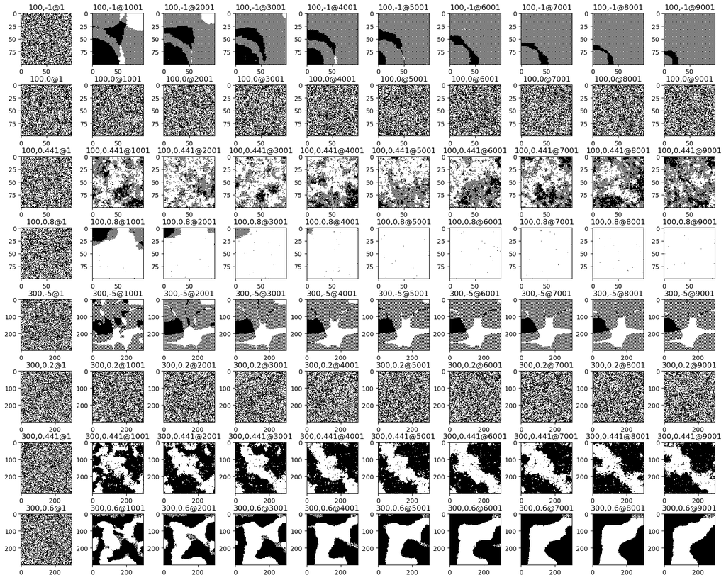

```
Simluation time elapsed:  0.11666011810302734
```

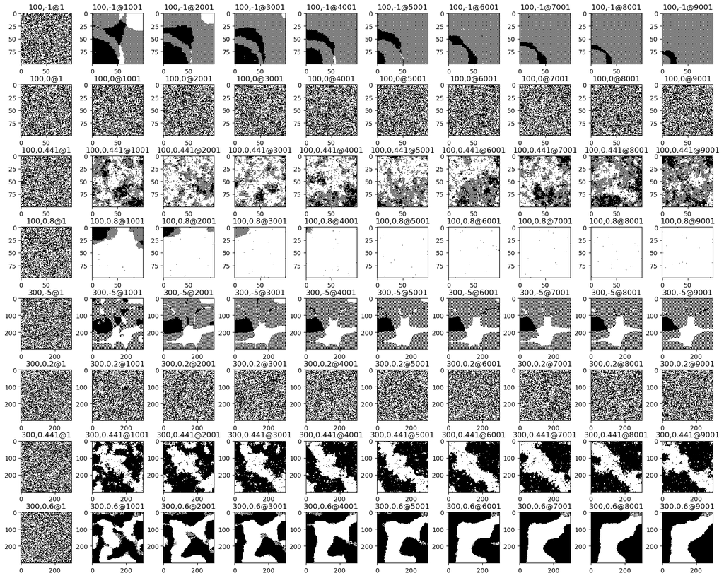

```python
import numpy as np
import matplotlib.pyplot as plt
from matplotlib.colors import ListedColormap
from IPython.display import clear_output
from time import sleep, time
import taichi as ti

ti.init(arch=ti.cuda)

@ti.data_oriented
class IsingModel:
    def __init__(self, n, beta):
        self.n = n
        self.beta = beta
        self.lattice = ti.field(dtype=ti.i32, shape=(n, n))
        self.initialize_lattice()

    @ti.kernel
    def initialize_lattice(self):
        for i, j in self.lattice:
            self.lattice[i, j] = ti.random(ti.i32) * 2 - 1

    @ti.kernel
    def simulate(self):
        for i, j in self.lattice:
            x = 0
            if i - 1 >= 0:
                x += self.lattice[i - 1, j]
            if i + 1 < self.n:
                x += self.lattice[i + 1, j]
            if j - 1 >= 0:
                x += self.lattice[i, j - 1]
            if j + 1 < self.n:
                x += self.lattice[i, j + 1]

            if ti.random() <= 1 / (1 + ti.exp(-2 * self.beta * x)):
                self.lattice[i, j] = 1
            else:
                self.lattice[i, j] = -1

    def show(self, index, n):
        clear_output(wait=True)
        plt.subplot(8, 10, index)
        cmap = ListedColormap(["0", "1"])
        plt.imshow(self.lattice.to_numpy(), cmap=cmap)
        plt.title(f"{self.n},{self.beta}@{n}")
        display(plt.gcf())


startTime = time()
plt.figure(figsize=(20, 16))
plt.subplots_adjust(hspace=0.4, wspace=0.4)
index = 0
for n, betas in [(100, [-1, 0, 0.441, 0.8]), (300, [-5, 0.2, 0.441, 0.6])]:
    for beta in betas:
        model = IsingModel(n, beta)
        for i in range(10000):
            model.simulate()
            if i % 1000 == 0:
                index += 1
                model.show(index, i+1)
                # print("500 Epoch time elapsed: ", time() - startTime)
                startTime = time()
print("Simluation time elapsed: ", time() - startTime)
```